# Ford GoBike Data Exploration

## by Chibuike Lawrence Orji-Oko

## Introduction

> This is an exploration of the Ford GoBike dataset. The Ford GoBike Dataset consists of information about individual rides made in a bike-sharing system covering greater San Francisco. The data features include duration (secs) and others such as DateTime, customer type, gender, and some additional variables.

## Preliminary Wrangling

```python
# import all packages and set plots to be embedded inline
import numpy as np
import pandas as pd
import matplotlib.pyplot as plt
import seaborn as sns

%matplotlib inline
import warnings
warnings.filterwarnings('ignore')
```

```python
# load in the dataset into a pandas dataframe
df = pd.read_csv('201902-fordgobike-tripdata.csv')
```

```python
#Short overview of the dataframe
df.head(5)
```

|  | duration_sec | start_time | end_time | start_station_id | start_station_name | start_station_latitude | start_station_longitude | end_station_id | end_station_name | end_station_latitude | end_station_longitude | bike_id | user_type | member_birth_year | member_gender | bike_share_for_all_trip |
| --- | --- | --- | --- | --- | --- | --- | --- | --- | --- | --- | --- | --- | --- | --- | --- | --- |
| 0 | 52185 | 2019-02-28 17:32:10.1450 | 2019-03-01 08:01:55.9750 | 21.0 | Montgomery St BART Station (Market St at 2nd St) | 37.789625 | -122.400811 | 13.0 | Commercial St at Montgomery St | 37.794231 | -122.402923 | 4902 | Customer | 1984.0 | Male | No |
| 1 | 42521 | 2019-02-28 18:53:21.7890 | 2019-03-01 06:42:03.0560 | 23.0 | The Embarcadero at Steuart St | 37.791464 | -122.391034 | 81.0 | Berry St at 4th St | 37.775880 | -122.393170 | 2535 | Customer | NaN | NaN | No |
| 2 | 61854 | 2019-02-28 12:13:13.2180 | 2019-03-01 05:24:08.1460 | 86.0 | Market St at Dolores St | 37.769305 | -122.426826 | 3.0 | Powell St BART Station (Market St at 4th St) | 37.786375 | -122.404904 | 5905 | Customer | 1972.0 | Male | No |
| 3 | 36490 | 2019-02-28 17:54:26.0100 | 2019-03-01 04:02:36.8420 | 375.0 | Grove St at Masonic Ave | 37.774836 | -122.446546 | 70.0 | Central Ave at Fell St | 37.773311 | -122.444293 | 6638 | Subscriber | 1989.0 | Other | No |
| 4 | 1585 | 2019-02-28 23:54:18.5490 | 2019-03-01 00:20:44.0740 | 7.0 | Frank H Ogawa Plaza | 37.804562 | -122.271738 | 222.0 | 10th Ave at E 15th St | 37.792714 | -122.248780 | 4898 | Subscriber | 1974.0 | Male | Yes |

```python
# high-level overview of data shape and composition
print(df.shape)
print() # To reate space betweeen the outputs
print(df.dtypes)
print()
print(df.info())
```

```
(183412, 16)

duration_sec                 int64
start_time                  object
end_time                    object
start_station_id           float64
start_station_name          object
start_station_latitude     float64
start_station_longitude    float64
end_station_id             float64
end_station_name            object
end_station_latitude       float64
end_station_longitude      float64
bike_id                      int64
user_type                   object
member_birth_year          float64
member_gender               object
bike_share_for_all_trip     object
dtype: object

<class 'pandas.core.frame.DataFrame'>
RangeIndex: 183412 entries, 0 to 183411
Data columns (total 16 columns):
 #   Column                   Non-Null Count   Dtype
---  ------                   --------------   -----
 0   duration_sec             183412 non-null  int64
 1   start_time               183412 non-null  object
 2   end_time                 183412 non-null  object
 3   start_station_id         183215 non-null  float64
 4   start_station_name       183215 non-null  object
 5   start_station_latitude   183412 non-null  float64
 6   start_station_longitude  183412 non-null  float64
 7   end_station_id           183215 non-null  float64
 8   end_station_name         183215 non-null  object
 9   end_station_latitude     183412 non-null  float64
 10  end_station_longitude    183412 non-null  float64
 11  bike_id                  183412 non-null  int64
 12  user_type                183412 non-null  object
 13  member_birth_year        175147 non-null  float64
 14  member_gender            175147 non-null  object
 15  bike_share_for_all_trip  183412 non-null  object
dtypes: float64(7), int64(2), object(7)
memory usage: 22.4+ MB
None
```

### Insight: Wrong Data Types

`start_time` and `end_time` are object data type.

`start_station_id` and `end_station_id` columns are float data type.

`bike_id` column is an integer data type.

`member_birth_year` column is a float data type.

`user_type` and `member_gender` are object data type.

```python
# check for null values
df.isnull().sum()
```

```
duration_sec                  0
start_time                    0
end_time                      0
start_station_id            197
start_station_name          197
start_station_latitude        0
start_station_longitude       0
end_station_id              197
end_station_name            197
end_station_latitude          0
end_station_longitude         0
bike_id                       0
user_type                     0
member_birth_year          8265
member_gender              8265
bike_share_for_all_trip       0
dtype: int64
```

### Insight:

> Null values in the following columns: `start_station_id`, `start_station_name`, `end_station_id`, `end_station_name`, `member_birth_year`, and `member_gender`.

```python
# Check values in each column
df.nunique()
```

```
duration_sec                 4752
start_time                 183401
end_time                   183397
start_station_id              329
start_station_name            329
start_station_latitude        334
start_station_longitude       335
end_station_id                329
end_station_name              329
end_station_latitude          335
end_station_longitude         335
bike_id                      4646
user_type                       2
member_birth_year              75
member_gender                   3
bike_share_for_all_trip         2
dtype: int64
```

## Data Cleaning

#### Issue #1: Columns with wrong data types

#### Define: Convert the columns to the appropriate data types

```python
df['start_time'] = df['start_time'].astype('datetime64[ns]') # from object data type to datetime
df['end_time'] = df['end_time'].astype('datetime64[ns]')     # from object data type to datetime
df['start_station_id'] = df['start_station_id'].astype(str)  # from float data type to string (object)
df['end_station_id'] = df['end_station_id'].astype(str)      # from float data type to string (object)
df['bike_id'] = df['bike_id'].astype(str)                    # from integer data type to string (object)
df['member_gender'] = df['member_gender'].astype('category') # from string (object) data type to category
df['user_type'] = df['user_type'].astype('category')         # from string (object) data type to category
```

#### Issue #2: Replace missing values in both member_gender and member_birth_year columns

```python
# Replace missing values in member_gender column
df['member_gender'].fillna(df['member_gender'].mode()[0], inplace=True)
```

```python
df['member_gender'].isnull().sum()
```

```
0
```

```python
# Replace missing values in member_birth_year column
df['member_birth_year'] = df['member_birth_year'].fillna(df['member_birth_year'].mean())
```

```python
df['member_birth_year'].isnull().sum()
```

```
0
```

#### Issue #3: Convert "member_birth_year" column from float data type to integer data type

```python
df['member_birth_year'] = df['member_birth_year'].astype(int)  # from float data type to integer
```

```python
# check for null values
df.isnull().sum()
```

```
duration_sec                 0
start_time                   0
end_time                     0
start_station_id             0
start_station_name         197
start_station_latitude       0
start_station_longitude      0
end_station_id               0
end_station_name           197
end_station_latitude         0
end_station_longitude        0
bike_id                      0
user_type                    0
member_birth_year            0
member_gender                0
bike_share_for_all_trip      0
dtype: int64
```

**NB: for now we will not be dropping the rows with missing values in start_station_name and end_station_name columns since these columns will not affect our analysis**

```python
df.info()
```

```
<class 'pandas.core.frame.DataFrame'>
RangeIndex: 183412 entries, 0 to 183411
Data columns (total 16 columns):
 #   Column                   Non-Null Count   Dtype
---  ------                   --------------   -----
 0   duration_sec             183412 non-null  int64
 1   start_time               183412 non-null  datetime64[ns]
 2   end_time                 183412 non-null  datetime64[ns]
 3   start_station_id         183412 non-null  object
 4   start_station_name       183215 non-null  object
 5   start_station_latitude   183412 non-null  float64
 6   start_station_longitude  183412 non-null  float64
 7   end_station_id           183412 non-null  object
 8   end_station_name         183215 non-null  object
 9   end_station_latitude     183412 non-null  float64
 10  end_station_longitude    183412 non-null  float64
 11  bike_id                  183412 non-null  object
 12  user_type                183412 non-null  category
 13  member_birth_year        183412 non-null  int32
 14  member_gender            183412 non-null  category
 15  bike_share_for_all_trip  183412 non-null  object
dtypes: category(2), datetime64[ns](2), float64(4), int32(1), int64(1), object(6)
memory usage: 19.2+ MB
```

```python
df.head(5)
```

|  | duration_sec | start_time | end_time | start_station_id | start_station_name | start_station_latitude | start_station_longitude | end_station_id | end_station_name | end_station_latitude | end_station_longitude | bike_id | user_type | member_birth_year | member_gender | bike_share_for_all_trip |
| --- | --- | --- | --- | --- | --- | --- | --- | --- | --- | --- | --- | --- | --- | --- | --- | --- |
| 0 | 52185 | 2019-02-28 17:32:10.145 | 2019-03-01 08:01:55.975 | 21.0 | Montgomery St BART Station (Market St at 2nd St) | 37.789625 | -122.400811 | 13.0 | Commercial St at Montgomery St | 37.794231 | -122.402923 | 4902 | Customer | 1984 | Male | No |
| 1 | 42521 | 2019-02-28 18:53:21.789 | 2019-03-01 06:42:03.056 | 23.0 | The Embarcadero at Steuart St | 37.791464 | -122.391034 | 81.0 | Berry St at 4th St | 37.775880 | -122.393170 | 2535 | Customer | 1984 | Male | No |
| 2 | 61854 | 2019-02-28 12:13:13.218 | 2019-03-01 05:24:08.146 | 86.0 | Market St at Dolores St | 37.769305 | -122.426826 | 3.0 | Powell St BART Station (Market St at 4th St) | 37.786375 | -122.404904 | 5905 | Customer | 1972 | Male | No |
| 3 | 36490 | 2019-02-28 17:54:26.010 | 2019-03-01 04:02:36.842 | 375.0 | Grove St at Masonic Ave | 37.774836 | -122.446546 | 70.0 | Central Ave at Fell St | 37.773311 | -122.444293 | 6638 | Subscriber | 1989 | Other | No |
| 4 | 1585 | 2019-02-28 23:54:18.549 | 2019-03-01 00:20:44.074 | 7.0 | Frank H Ogawa Plaza | 37.804562 | -122.271738 | 222.0 | 10th Ave at E 15th St | 37.792714 | -122.248780 | 4898 | Subscriber | 1974 | Male | Yes |

```python
# descriptive statistics for the numeric variables
df.describe()
```

|  | duration_sec | start_station_latitude | start_station_longitude | end_station_latitude | end_station_longitude | member_birth_year |
| --- | --- | --- | --- | --- | --- | --- |
| count | 183412.000000 | 183412.000000 | 183412.000000 | 183412.000000 | 183412.000000 | 183412.000000 |
| mean | 726.078435 | 37.771223 | -122.352664 | 37.771427 | -122.352250 | 1984.770097 |
| std | 1794.389780 | 0.099581 | 0.117097 | 0.099490 | 0.116673 | 9.887534 |
| min | 61.000000 | 37.317298 | -122.453704 | 37.317298 | -122.453704 | 1878.000000 |
| 25% | 325.000000 | 37.770083 | -122.412408 | 37.770407 | -122.411726 | 1981.000000 |
| 50% | 514.000000 | 37.780760 | -122.398285 | 37.781010 | -122.398279 | 1987.000000 |
| 75% | 796.000000 | 37.797280 | -122.286533 | 37.797320 | -122.288045 | 1992.000000 |
| max | 85444.000000 | 37.880222 | -121.874119 | 37.880222 | -121.874119 | 2001.000000 |

### What is the structure of your dataset?

> There are 183412 rides (rows) in the dataset with 16 features (columns). There are 2 datetime, 4 float, 2 integer, 6 string (object) and 2 categorical variables.

### What is/are the main feature(s) of interest in your dataset?

> Interested in learning more about the users and what time of the day were most ride taken.

### What features in the dataset do you think will help support your investigation into your feature(s) of interest?

> The duration, member_gender, bike_share_for_all_trip, start_date and end_date will provide me the information needed for this findings. We can extract the day, week, and month features from the start_date and end_date columns.

## Univariate Exploration

### What is the distribution of type of users

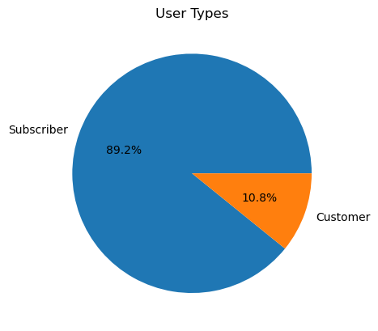

```python
users = df['user_type'].value_counts()/df['user_type'].value_counts().sum()
plt.pie(users, labels = users.index, autopct='%1.1f%%')
plt.title('User Types');
```

### Insight:

> We observe from the pie chart above that most of the Ford GoBike users are subscribers.

## What is the distribution of member gender?

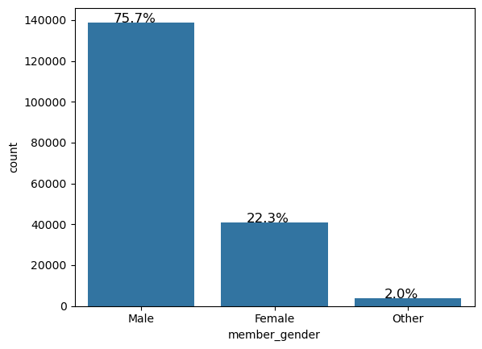

```python
gender_order = df['member_gender'].value_counts().index
base_color = sns.color_palette()[0]
ax = sns.countplot(data=df, x='member_gender', color=base_color, order=gender_order)

total = len(df)
for p in ax.patches:
    percentage = '{:.1f}%'.format(100 * p.get_height()/total)
    x = p.get_x() + p.get_width() / 2 - 0.05
    y = p.get_y() + p.get_height()
    ax.annotate(percentage, (x, y), size = 12, ha='center')
plt.show();
```

### Insight:

> Most users are males. 75.74% of the users of the Ford GoBike system are males while 22.27% are females. Those that filled "other" as gender account for 1.99% of the total rides.

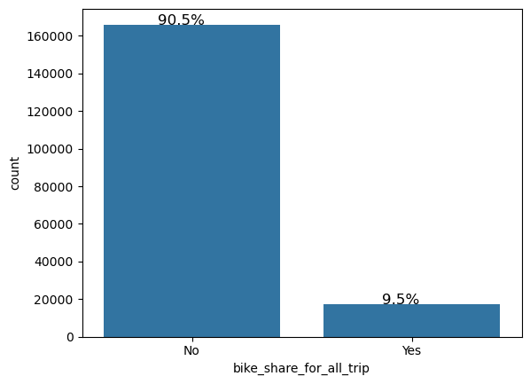

```python
share_order = df['bike_share_for_all_trip'].value_counts().index
base_color = sns.color_palette()[0]
ax = sns.countplot(data=df, x='bike_share_for_all_trip', color=base_color, order=share_order)

total = len(df)
for p in ax.patches:
    percentage = '{:.1f}%'.format(100 * p.get_height()/total)
    x = p.get_x() + p.get_width() / 2 - 0.05
    y = p.get_y() + p.get_height()
    ax.annotate(percentage, (x, y), size = 12, ha='center')
plt.show();
```

### Insight:

> Most rides are non bike sharing for all trip (90.5%).

## What is the age distribution?

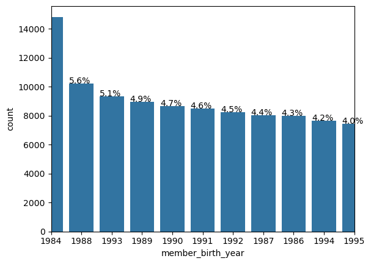

```python
birth_order = df['member_birth_year'].value_counts().index
base_color = sns.color_palette()[0]
ax = sns.countplot(data=df, x='member_birth_year', color=base_color, order=birth_order)
plt.xlim(0,10)
total = len(df)
for p in ax.patches:
    percentage = '{:.1f}%'.format(100 * p.get_height()/total)
    x = p.get_x() + p.get_width() / 2 - 0.05
    y = p.get_y() + p.get_height()
    ax.annotate(percentage, (x, y), size = 10, ha='center')

plt.show();
```

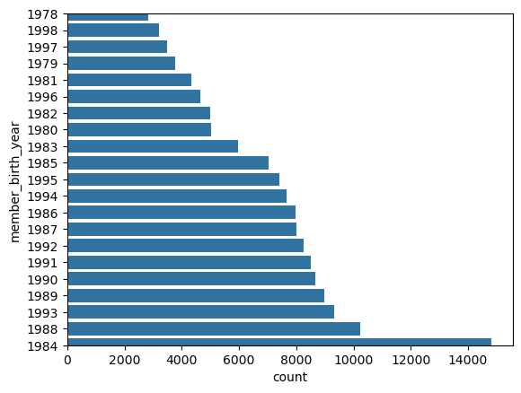

```python
birth_order = df['member_birth_year'].value_counts().index
base_color = sns.color_palette()[0]
sns.countplot(data=df, y='member_birth_year', color=base_color, order=birth_order)
plt.ylim((0,20));
```

```python
df['member_birth_year'].value_counts().head(20)
```

```
1984    14827
1988    10236
1993     9325
1989     8972
1990     8658
1991     8498
1992     8250
1987     8018
1986     7973
1994     7660
1995     7423
1985     7028
1983     5954
1980     5024
1982     4990
1996     4640
1981     4345
1979     3756
1997     3481
1998     3208
Name: member_birth_year, dtype: int64
```

```python
sum_1979_1998 = df['member_birth_year'].value_counts().head(20).sum()
total_num = df.shape[0]
percent_1979_1998 = (sum_1979_1998/total_num)*100
print('{:.1f}%'.format(percent_1979_1998))
```

```
77.6%
```

### Insight:

> There are 75 different birth year groups of Ford GoBike users. 20 (1979 - 1998) out of the 75 different age group accounts for 77.6% of the entire users of Ford GoBike system.

## What time of the day were the trips taken?

```python
# Extracting hour, day, and month colunns fron the start_time and end_time columns

import datetime as dt
df['start_hour'] = df['start_time'].dt.hour
df['start_hour'] = df['start_hour'].astype(str)
df['start_day'] = df['start_time'].dt.day_name()
df['start_month'] = df['start_time'].dt.month_name()

df['end_hour'] = df['end_time'].dt.hour
df['end_hour'] = df['start_hour'].astype(str)
df['end_day'] = df['end_time'].dt.day_name()
df['end_month'] = df['end_time'].dt.month_name()
```

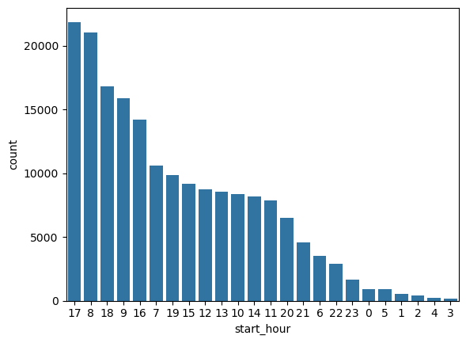

```python
hour_order = df['start_hour'].value_counts().index
base_color = sns.color_palette()[0]
sns.countplot(data=df, x='start_hour', color=base_color, order=hour_order)
```

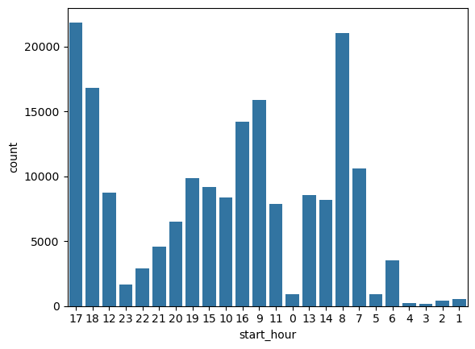

```python
base_color = sns.color_palette()[0]
sns.countplot(data=df, x='start_hour', color=base_color)
```

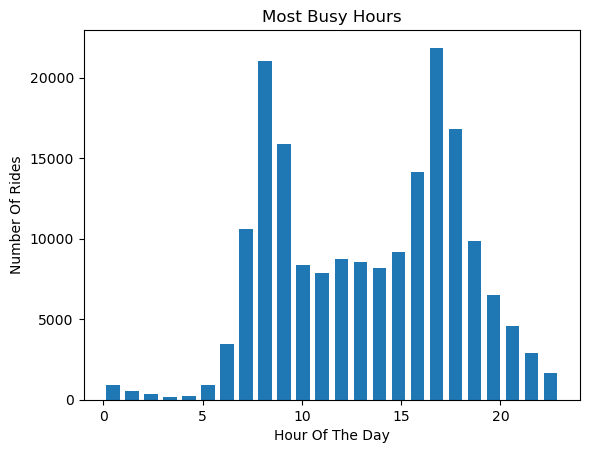

```python
# number of rides by hours of the day
data = df['start_time'].dt.hour
plt.hist(data,rwidth=.7, bins = 24)
plt.title('Most Busy Hours')
plt.xlabel('Hour Of The Day')
plt.ylabel('Number Of Rides');
```

### Insight:

> The distribution is bimodal. The two peaks are during the normal rush hours of a day. The first peak is between the hours of 7AM and 9AM when people are going to work. And the second peak is between the hours of 4PM and 6PM when people are returning back from work.

## What day of the week were the trips taken?

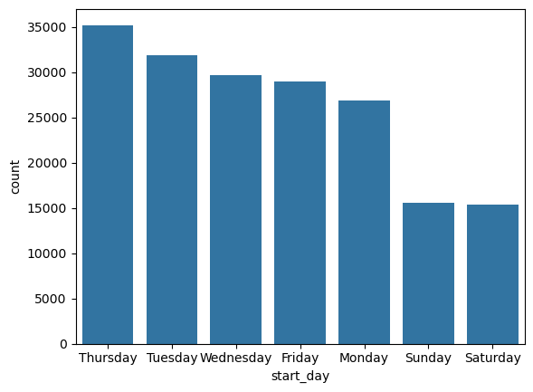

```python
day_order = df['start_day'].value_counts().index
base_color = sns.color_palette()[0]
sns.countplot(data=df, x='start_day', color=base_color, order=day_order);
```

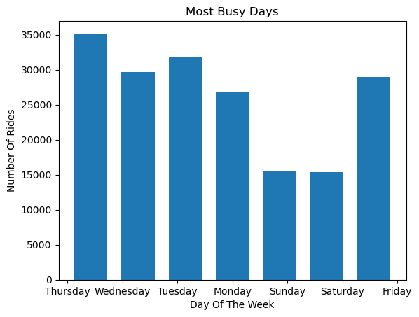

```python
# number of rides by days of the week
data = df['start_time'].dt.day_name()
plt.hist(data,rwidth=.7, bins = 7)
plt.title('Most Busy Days')
plt.xlabel('Day Of The Week')
plt.ylabel('Number Of Rides');
```

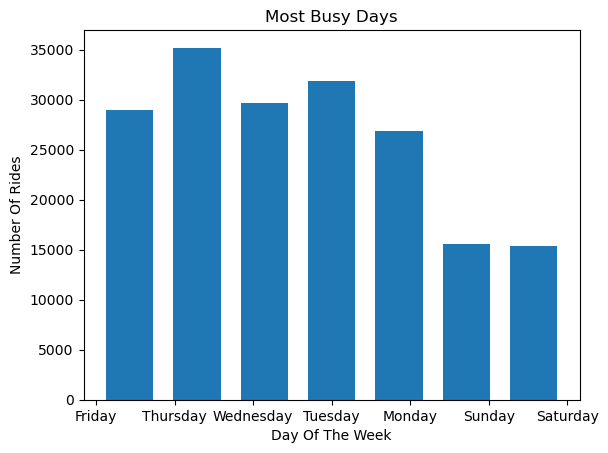

```python
# number of rides by days of the week
data = df['end_time'].dt.day_name()
plt.hist(data,rwidth=.7, bins = 7)
plt.title('Most Busy Days')
plt.xlabel('Day Of The Week')
plt.ylabel('Number Of Rides');
```

### Insight:

> Thurday have the highest number of trips, followed by Tueday. While weekends (Saturday and Sunday) have the lowest rides.

## What is the average ride duration?

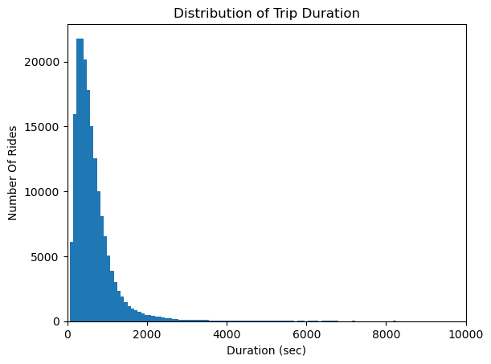

```python
#Distribution of duration of rides
data = df['duration_sec']
plt.hist(data , bins = 1000 )
plt.xlim(0,10000)
plt.title('Distribution of Trip Duration')
plt.xlabel('Duration (sec)')
plt.ylabel('Number Of Rides');
```

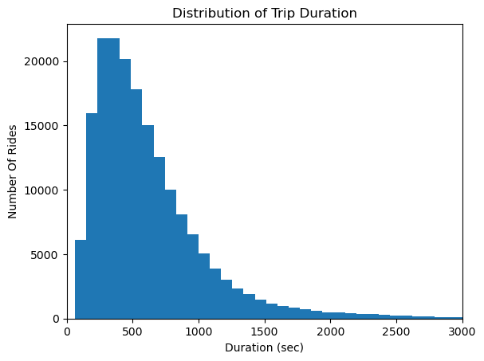

```python
#Distribution of duration of rides
data = df['duration_sec']
plt.hist(data , bins = 1000 )
plt.xlim(0,3000)
plt.title('Distribution of Trip Duration')
plt.xlabel('Duration (sec)')
plt.ylabel('Number Of Rides');
```

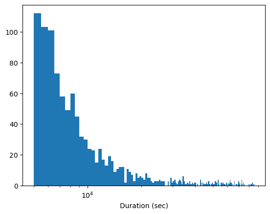

```python
bins = np.arange(5000, df['duration_sec'].max()+500,500)
plt.hist(data=df, x='duration_sec', bins=bins)
plt.xlabel('Duration (sec)')
plt.xscale('log');
```

```python
np.log10(df.duration_sec.describe())
```

```
count    5.263428
mean     2.860984
std      3.253917
min      1.785330
25%      2.511883
50%      2.710963
75%      2.900913
max      4.931682
Name: duration_sec, dtype: float64
```

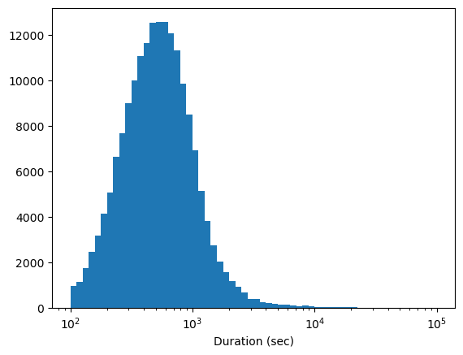

```python
bins = 10 ** np.arange(2, 5+0.05, 0.05)
plt.hist(data=df, x='duration_sec', bins=bins)
plt.xlabel('Duration (sec)')
plt.xscale('log');
```

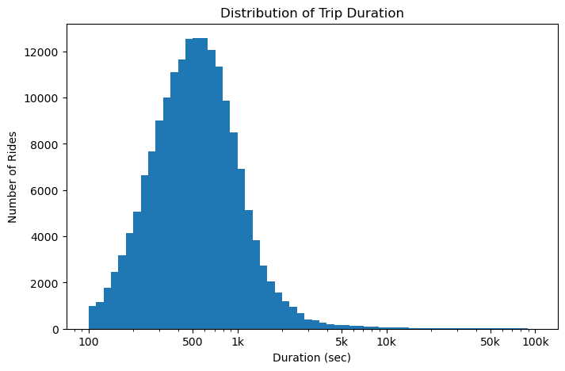

```python
bins = 10 ** np.arange(2, 5+0.05, 0.05)
#ticks = ('50', '100', '500', '1k', '5k', '10k', '50k', '100k')
#labels = ['{}'.format(v) for v in ticks]
plt.figure(figsize=[8, 5])
plt.hist(data=df, x='duration_sec', bins=bins)
plt.xscale('log');
plt.title('Distribution of Trip Duration')
plt.xlabel('Duration (sec)')
plt.ylabel('Number of Rides');
plt.xticks([1e2, 5e2, 1e3, 5e3, 1e4, 5e4, 1e5], ['100', '500', '1k', '5k', '10k', '50k', '100k']);
```

### Insight:

> There are a lot of rides on the short duration end (100 - 1000 secs) and few on the long duration end. It has a peak at around 500 secs and a gradual decline till around 10k secs. There are fewer longer durations afterwards between 10k secs and 100k secs. From the graph we can conclude that the majority of the rides are under 30 minutes.

### Discuss the distribution(s) of your variable(s) of interest. Were there any unusual points? Did you need to perform any transformations?

> Most of the distributions are pretty normal. The majority users are subscribers with a very high percentage of male customers as expected. The busiest hours being during the rush hour time of the day. The unusual point we have found however is the distribution of rides when we look at each day of the wek. I did not expect the busiest day to be Thursday. I extracted hour, day, and month from the start_time and end_time columns.

## Bivariate Exploration

> In this section, investigate relationships between pairs of variables in your data.

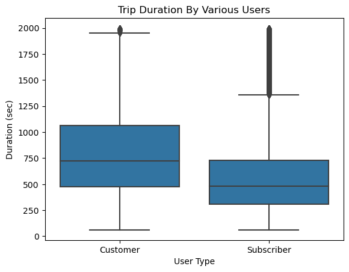

```python
# Comparing user types and ride duration
base_color = sns.color_palette()[0]
duration = df[df['duration_sec'] < 2000]
sns.boxplot(data=duration , x='user_type', y='duration_sec', color=base_color)
plt.title('Trip Duration By Various Users')
plt.ylabel('Duration (sec)')
plt.xlabel('User Type');
```

### Insight:

> The boxplot shows that customers on average take longer trips than subscribers. There are many outliers on the subscriber feature.

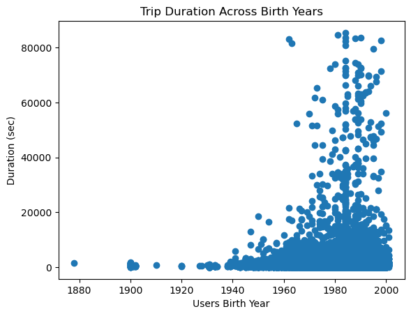

```python
plt.scatter(data=df, y='duration_sec', x='member_birth_year');
plt.xlabel('Users Birth Year')
plt.ylabel('Duration (sec)')
plt.title('Trip Duration Across Birth Years');
```

### Insight:

> Most trips were taken by persons born between 1978 and 2000.

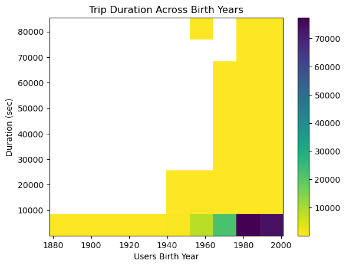

```python
plt.hist2d(data=df, y='duration_sec', x='member_birth_year', cmin=0.5, cmap='viridis_r');
plt.colorbar();
plt.xlabel('Users Birth Year')
plt.ylabel('Duration (sec)')
plt.title('Trip Duration Across Birth Years');
```

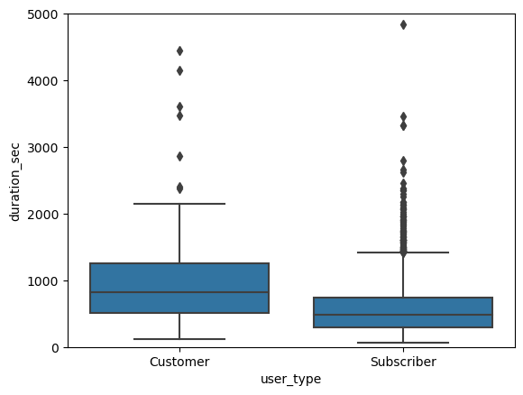

```python
base_color = sns.color_palette()[0]
samples = np.random.choice(df.shape[0], 2000, replace = False)
df_sample = df.loc[samples,:]
sns.boxplot(data=df_sample, y='duration_sec', x='user_type', color=base_color);
plt.ylim([0,5000]);
```

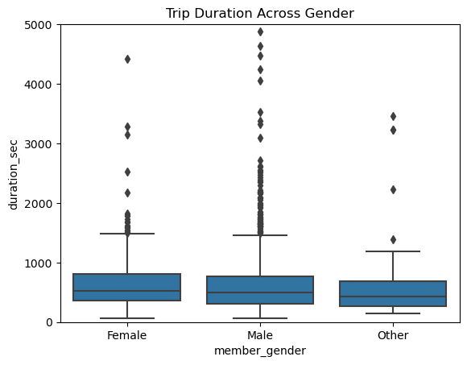

```python
base_color = sns.color_palette()[0]
samples = np.random.choice(df.shape[0], 2000, replace = False)
df_sample = df.loc[samples,:]
sns.boxplot(data=df_sample, y='duration_sec', x='member_gender', color=base_color);
plt.ylim([0,5000]);
plt.title('Trip Duration Across Gender');
```

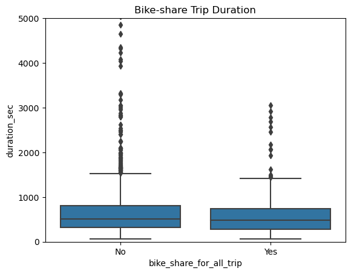

```python
base_color = sns.color_palette()[0]
samples = np.random.choice(df.shape[0], 2000, replace = False)
df_sample = df.loc[samples,:]
sns.boxplot(data=df_sample, y='duration_sec', x='bike_share_for_all_trip', color=base_color);
plt.ylim([0,5000]);
plt.title('Bike-share Trip Duration');
```

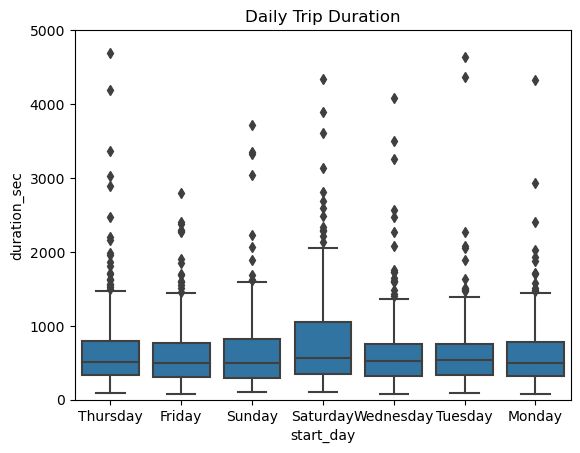

```python
base_color = sns.color_palette()[0]
samples = np.random.choice(df.shape[0], 2000, replace = False)
df_sample = df.loc[samples,:]
sns.boxplot(data=df_sample, y='duration_sec', x='start_day', color=base_color);
plt.ylim([0,5000]);
plt.title('Daily Trip Duration');
```

```python
counts = df.groupby(['start_day', 'user_type']).size()
counts = counts.reset_index(name = 'count')
counts = counts.pivot(index='start_day', columns='user_type', values='count')
counts
```

| user_type start_day | Customer | Subscriber |
| --- | --- | --- |
| Friday | 3030 | 25951 |
| Monday | 2741 | 24111 |
| Saturday | 2739 | 12666 |
| Sunday | 2896 | 12627 |
| Thursday | 3390 | 31807 |
| Tuesday | 2606 | 29207 |
| Wednesday | 2466 | 27175 |

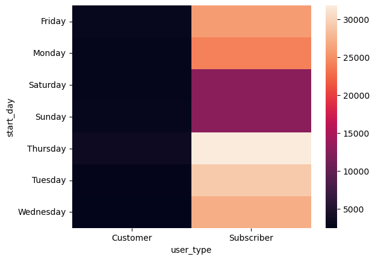

```python
sns.heatmap(counts);
```

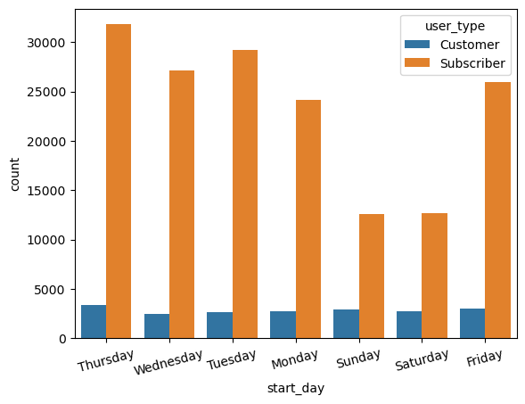

```python
sns.countplot(data=df, x='start_day', hue='user_type');
plt.xticks(rotation=15);
```

### Insight:

> Customers have little effect on the number of trips across each day of the week.

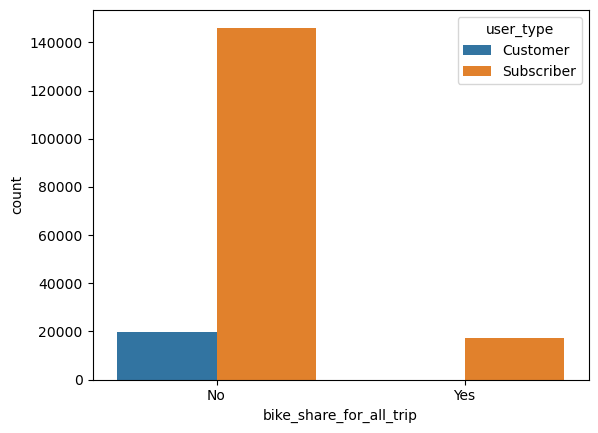

```python
sns.countplot(data=df, x='bike_share_for_all_trip', hue='user_type');
```

### Insight:

> Bike-sharing service are used only by subscibers. The number of trips taken by subscribers on a non bike-sharing mode is far higher than those by bike-sharing.

### Talk about some of the relationships you observed in this part of the investigation. How did the feature(s) of interest vary with other features in the dataset?

> The customer type users spend more time on average compare to subscribers while the female gender spend slightly higher time on average than male. Also non bike share and bike share for all trip appears to be similar.

### Did you observe any interesting relationships between the other features (not the main feature(s) of interest)?

> We observed that customer type riders have little efect on the number of trips in any week day. There both male and female genders that are subscriber and customer users. Also bike-sharing service seems to be available to subscibers.

## Multivariate Exploration

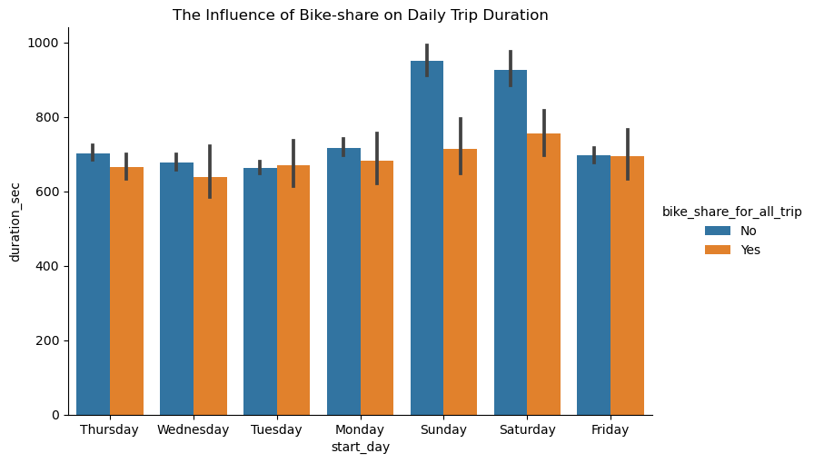

```python
sns.catplot(data=df, kind="bar", x="start_day", y="duration_sec", hue="bike_share_for_all_trip", aspect=1.5);
plt.title('The Influence of Bike-share on Daily Trip Duration');
```

### Insight:

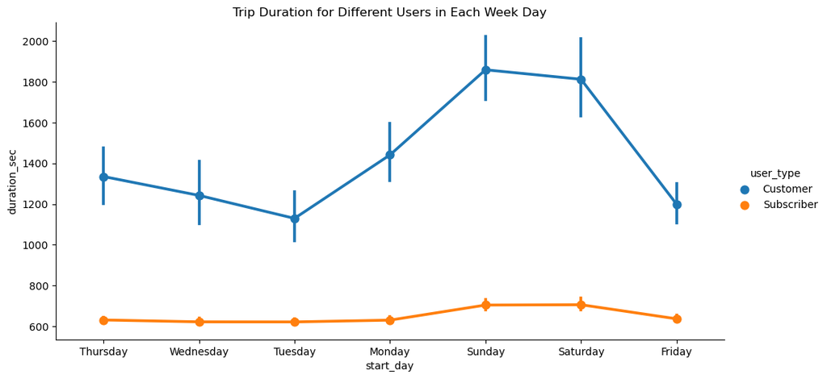

```python
sns.catplot(data=df, kind="point", x="start_day", y="duration_sec", hue="user_type", aspect=2);
plt.title('Trip Duration for Different Users in Each Week Day');
```

### Insight:

> Customers on the average take longer trips than subscribers throuhgout the week but most on Saturdays and Sundays. While subscribers generally travel over short time with litle increase during weekends.

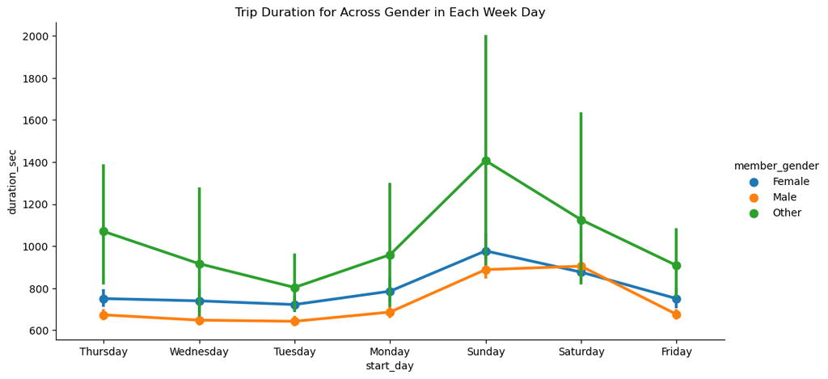

```python
sns.catplot(data=df, kind="point", x="start_day", y='duration_sec', hue="member_gender", aspect=2);
plt.title('Trip Duration for Across Gender in Each Week Day');
```

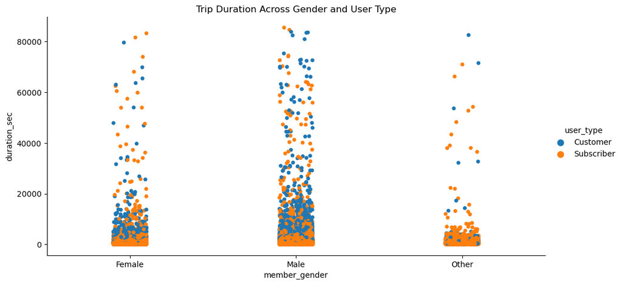

```python
sns.catplot(data=df, kind="strip", x="member_gender", y='duration_sec', hue="user_type", aspect=2);
plt.title('Trip Duration Across Gender and User Type');
```

### Insight:

> Most of the trip for each category happended with 10000 seconds.

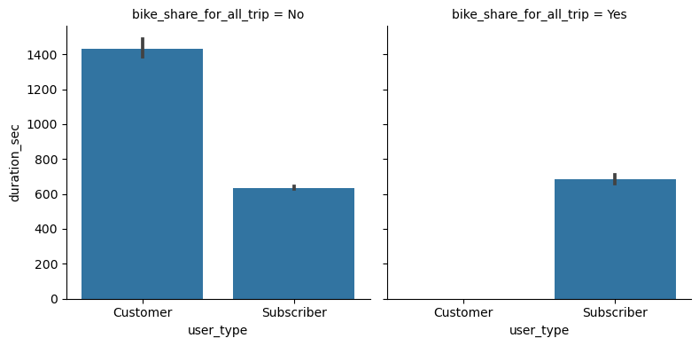

```python
base_color = sns.color_palette()[0]
sns.catplot(data=df, kind="bar", x="user_type", y='duration_sec', col="bike_share_for_all_trip", aspect=1,
            height=4, color=base_color);
#plt.title("The Effect of Bike-Share on Various Users' Trip Duration");
```

### Insight:

> Customers did not make use of bike-share service. Subscribers with bike-share on the avarage have slightly longer trips than subscribers with non bike-share.

## Conclusions

Most of the Ford GoBike users are subscribers (89.2%).

The majority of the rides are under 30 minutes.

The most busy hours are during the rush hours of a day, between the hours of 7AM and 9AM when people are going to work, and between the hours of 4PM and 6PM when people are returning back from work.

Thursdays have the hightest trips, followed by Tuedays. While weekends (Saturdays and Sundays) have the lowest rides.

Most riders are males. 75.74% of the users of the Ford GoBike system are males while 22.27% are females. Those that filled "other" as gender account for 1.99% of the total rides.

Non bike-sharing is preferred more than bike-sharing.

Customers on the average take longer trips than subscribers.

Subscribers use Ford GoBike for short distance travels while customers take longer rides.

## References:

https://video.udacity-data.com/topher/2020/October/5f91cf38_201902-fordgobike-tripdata/201902-fordgobike-tripdata.csv

https://video.udacity-data.com/topher/2021/September/6155a85c_example-project/example-project.zip

https://matplotlib.org/stable/api/_as_gen/matplotlib.pyplot.plot.html

https://seaborn.pydata.org/tutorial/introduction